# Lecture 12: From Broadcast to Blockchains

### Announcements

- Please pick up your card
- Due Friday 10/17 at 6pm on Gradescope
  - Reading Assessment 6, covering [Shi sections 5-6](https://elaineshi.com/docs/blockchain-book.pdf)
  - Homework 5
- Test 2 on Wed 10/22 on Unit 2 (Lectures 8-12, Labs 4-6, Reading 4-6, and Homework 4-5)

### Learning outcomes

By the end of today’s lecture, you will learn:

- How randomness can improve Byzantine Broadcast, at least if we move away from a strict worst-case notion of security and allow a small probability of error
- How to design a permissioned blockchain, given any Byzantine Broadcast protocol and fair coin tossing protocol

### Review from last lecture

Bitcoin carefully constructs and combines two components: *broadcast* and *leader election*. This week we ask the question:

> Can we build a blockchain to achieve consensus on messages sent over the Internet with no proof of work? No miners? Maybe not even a cryptocurrency?

In the **Byzantine Broadcast** problem:

- The *leader* is trying to send a message to everyone
- All honest *parties* want to reach common knowledge on a message

There are a total of $n$ parties, including the leader. An unknown subset of $t$ parties is malicious.

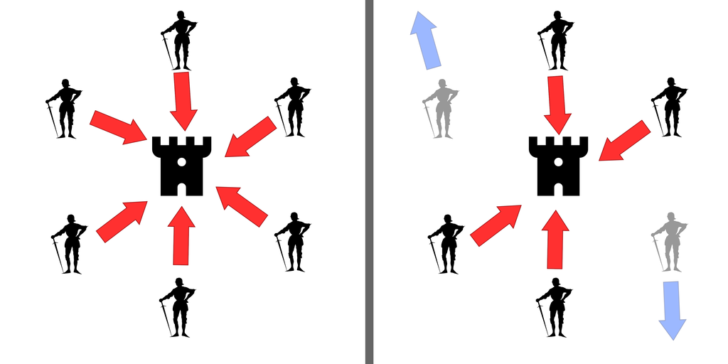

Byzantine Broadcast (image source: [Wikipedia](https://upload.wikimedia.org/wikipedia/commons/f/fc/Byzantine_Generals.png))

Synchronous Byzantine Broadcast protocols must satisfy three requirements.

- **Termination**: the protocol eventually ends
- **Consistency**: all honest parties agree on the *same* output
- **Validity**: if the leader is honest, then all honest parties agree on the *desired* output from the leader

Here is a high-level description of the phase-king protocol:

- It proceeds in $t+1$ phases, and one party is the “king” in each phase, starting with the leader
- Each phase contains 3 rounds of communication: the king sends a message to everyone, and then the parties use `Gradecast` to check if their messages are consistent

This protocol satisfies:

- Validity because an honest leader will send a consistent message to everyone in the first phase, after which everyone will become “stubborn” and keep this message forever
- Consistency after the first phase that is run by an honest king (if not earlier) because an honest king will send the same message to everyone

## 12.1 The power of randomness

Let’s continue our exploration of Byzantine Broadcast in the synchronous model. Note that both Dolev-Strong and phase-king require at least $t$ rounds to reach consensus.

|  | Dolev-Strong | Phase-King |
| --- | --- | --- |
| Number of malicious parties | $t \leq n$ | $t \leq \frac{n-1}{3}$ |
| Synchronous network | YES | YES |
| PKI | YES | NO |
| Number of rounds | $t+1$ | $3(t+1)$ |

**Question.** Can we do better?

**Theorem 1 (Dolev-Strong)** No deterministic protocol (even with a PKI) can achieve Byzantine Broadcast in fewer than $t + 1$ rounds.

We are not going to prove this theorem generically. But let’s see why it is true for the phase-king protocol specifically.

- Consistency is only guaranteed after a phase that is run by an honest party
- In the worst case, it could be the case that our adversary has corrupted the first $t$ parties, so we need $t+1$ phases

But what if we consider a protocol that makes *random* and *unpredictable* choices? Can we do better? How could we even take advantage of randomness to foil the adversary?

### An assumption: CommonCoin

Let’s imagine that the $n$ parties can get together to flip a coin.

In the physical world, a coin is a powerful object that provides some nice guarantees.

- **Common view**: once the coin is flipped, everyone can agree on the result
- **Unpredictability**: no coalition of $t < n$ parties know what the result of the coin will be in advance.
- **Unbiasedness**: no coalition of $t < n$ parties can influence or bias the outcome of the coin away from a 50-50 chance of heads vs tails

If all $n$ parties are colluding together, then they can break these properties since they could just set the coin to be the value that they all like. But in this case, there is no honest party remaining to protect.

These properties are very cool! It would be great if we can build such a **CommonCoin** in the digital world.

I will show you at the end of today’s lecture how to build a CommonCoin protocol. For now, let’s just suppose that it exists. What can we do with a CommonCoin?

### Integrating CommonCoin into phase-king

Let’s return to our original question.

**Question.** Using a CommonCoin, can we build a Byzantine broadcast protocol that completes in fewer than $t+1$ rounds?

*Answer*. Here is one option:

- The leader acts as the king in the first phase, as usual
- In between phases, run the CommonCoin protocol to toss many coins, and use the sequence of heads/tails to select a new king
- Then run an iteration of the normal phase-king protocol: the randomly-elected king sends a message, and parties will adopt it unless they were already happy in a previous phase

Suppose that $n = 3t + 1$; that is, there are approximately $2/3$ honest parties and $1/3$ malicious parties. Let’s calculate how many phases of this protocol we need to run, in order to be convinced that there has been one phase led by an honest party with overwhelming probability.

- A CommonCoin guarantees that the choice of leader is unbiased, so each phase individually has a $2/3$ chance of being led by an honest party
- If we run for $k$ phases, then the probability that there are no honest leaders is $\left(\frac{1}{3}\right)^k$
- Hence, the probability of having at least one phase with an honest leader is $1 - \left(\frac{1}{3}\right)^k$

This is a powerful observation!

**Interactive question.** Suppose there are $n = \text{1,000,000}$ parties, and $t = \text{333,333}$ of them are malicious. With the deterministic phase-king protocol from the previous lecture, how many phases are required?

1. Between 10 and 100
2. Between 100 and 1000
3. Between 1000 and 1 million
4. Greater than 1 million

**Interactive question.** Suppose there are $n = \text{1,000,000}$ parties, and $t = \text{333,333}$ of them are malicious. With the randomized phase-king protocol that chooses each leader uniformly at random from a CommonCoin, how many phases are required to be 99.9999999999% certain of reaching consensus (i.e., with only 1 in a trillion error)?

1. Between 10 and 100
2. Between 100 and 1000
3. Between 1000 and 1 million
4. Greater than 1 million

*Answer*. Deterministic phase-king scales linearly with the number of parties, whereas randomized phase-king only depends on the probability of error.

- To be 100% certain of reaching consensus, we must run phase-king for $t+1 = \text{333,334}$ phases
- To be 99.9999999999% certain of reaching consensus (i.e., up to 1 in a trillion error), we must run 26 phases

## 12.2 Broadcast vs. blockchains

Let’s take state of where we stand in Unit 2.

- We started by exploring the question of how to design a decentralized mechanism that reliably records financial transactions. We constructed a mechanism for doing so: the Bitcoin **blockchain**.
- Then we delved into the question of how to **broadcast** a message to a known set of parties.

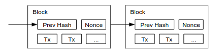

Blocks connected in a chain (image source: [Nakamoto whitepaper](https://bitcoin.org/bitcoin.pdf))

**Question.** How are these problems related?

There are some similarities between the problems:

- Both broadcast and blockchains involve the dissemination of data.
- Both have some notion of **consistency**: the idea that all parties (eventually) know the data, *and* they know that everyone else (who is honest) knows the data too.
- Both protocols are built on top of a network with point-to-point connections; that is, it allows any party to send data to each other party.

But also, there are at least four differences between broadcast and blockchains.

One-shot vs long-running:

- A Byzantine Broadcast is a one-shot protocol: the sender has data, the parties talk for some number of rounds/steps, and then it **terminates**
- By contrast, a blockchain can add new content forever, with the goal that each atomic unit of data, called a **transaction**, is eventually known by everyone

Computational power:

- Byzantine Broadcast protocols do not require that much computational power — at most some digital signatures, which can be computed in less than 1 millisecond on a laptop
- The Bitcoin protocol relies upon a proof of work puzzl, which consumes a **lot** of electricity in order to calculate about $10^{21}$ SHA-256 hash operations every second

[figure not shown]

Bitcoin’s SHA-256 hash rate, where a “zetahash” is $10^{21}$ hashes (image source: [blockchain.com](https://www.blockchain.com/explorer/charts))

Time to finalize a transaction:

- A Byzantine Broadcast protocol requires many rounds to reach consensus: $t+1$ phases for a 100% guarantee, or 26 phases (i.e., 78 rounds) for a probabilitic guarantee
- Within the Bitcoin blockchain, most people consider a block to be finalized (probabilistically) after about 6 or so blocks have been created afterward

Assumptions about the network:

- A broadcast protocol might assume that the underlying network is synchronous (e.g., Dolev-Strong or phase-king), or it may be flexible enough to operate over an asynchronous network
- The Bitcoin blockchain works even if the underlying network is asynchronous

That said, there is nothing that stops us from designing a blockchain that assumes that the network is synchronous. Let’s do that now.

## 12.3 Defining a blockchain

So far we have only seen a blockchain in one context: within the Bitcoin protocol.

Let’s abstract away from what we have seen in the Bitcoin context, and define the objectives of a “blockchain” more generically.

A blockchain has three types of data:

- A **transaction** `tx` is a single message. It could be a bit like 0 or 1, or a multi-bit message like “Alice pays Bob 1 coin, signed Alice.”
- A **block** is an unordered set of several messages, typically ones that are sent around the same time.
- A **log** is an *ordered* list of blocks. This chain is intended to be an append-only log; it only grows at the end, and never shrinks or changes in the middle.

**Definition 1 (Permissioned blockchain)** A permissioned blockchain protocol in the synchronous setting must distribute a log to all parties such that the following two requirements are satisfied.

- **Safety** (also called “*consistency*” in Shi’s textbook): all parties have the “same” view of the linearly-ordered log. But since the log may take some time to propagate, it’s acceptable if some parties record a block in their log before other ones do.

  Formally: for any pair of honest parties $i$ and $j$ and at any round $r$, it must be the case that party $i$’s log is a subset of party $j$’s log, or the other way around. (Note that the logs can be identical.)
- **Liveness**: there is some upper bound $\Delta$ on the number of rounds that it takes for a transaction to be included in the agreed-upon log.

  Formally: if an honest party receives a transaction `tx` at some round $r$, then by the end of round $r + \Delta$ all honest parties’ logs must include this transaction.

One more bit of terminology: once a single transaction `tx` reaches time $r + \Delta$, we say that the transaction is **finalized**. This means that it has been confirmed and cannot be undone, aka double-spent, from then onward.

## 12.4 From broadcast to blockchains

Let’s consider the following question: starting from a Byzantine Broadcast protocol, can we construct a blockchain?

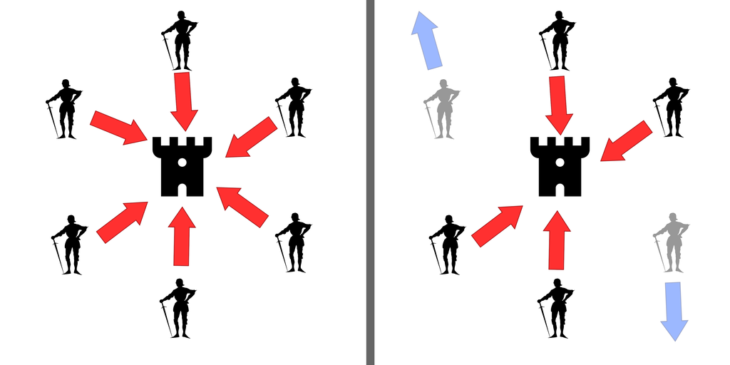

$\Longrightarrow$

[Image source: [Wikipedia](https://upload.wikimedia.org/wikipedia/commons/f/fc/Byzantine_Generals.png)]

For now, let’s limit consider the easiest options of all design parameters:

- There are a fixed collection of $n$ parties that participate in the blockchain protocol forever; no party ever enters or leaves the blockchain protocol in progress.
- Each of the $n$ parties knows the identity of the other $n-1$ parties, which is why we call this a **permissioned blockchain**. (By contrast, Bitcoin is a *permissionless blockchain*; anyone can become a node or a miner, and they don’t need to know each other.)
- Assume the network is synchronous (e.g., it proceeds in rounds that each take ~1 second).
- You can choose any threshold $t \geq 1$ of malicious parties that you want, and you can use a PKI setup if you want.

**Question.** How might we do this?

Here is one way to build a blockchain, starting from any $R$-round Byzantine Broadcast protocol. We will say that the protocol proceeds in several “epochs,” each of which last for $R$ rounds.

Epoch 1 (containing $R$ rounds):

- Party 1 is chosen as the leader. This party collects any transactions that it has heard, and forms a block.
- All parties execute an $R$-round Byzantine Broadcast, with Party 1 as the designated sender.
- At the end of this epoch of $R$ rounds: all honest parties have agreed upon some block, and furthermore if Party 1 is honest then the agreed-upon block will be the one that Party 1 chose. Honest parties add this block to their log.

Now repeat this cycle forever:

- In epoch 2 we elect Party 2 as the designated sender of an $R$-round Byzantine Broadcast protocol to add a block of their choice to the chain. In epoch 3 we elect Party 3 as the designated sender to propose a block to add, and so on.
- In epoch $n+1$ we go back to the beginning and elect Party 1 as the designated sender. And so on.

Impressively, this simple construction works! You can instantiate it with Dolev-Strong if a PKI is available, with phase-king if there is no setup, or any other Byzantine Broadcast protocol that you want.

**Theorem 2** Let BB denote any Byzantine Broadcast protocol in the synchronous setting, which can communicate messages from a particular set (e.g., one bit, or multi-bit messages) within $R$ rounds for a network of $n$ parties and tolerating up to $t$ malicious parties.

Then, the above blockchain construction satisfies safety and liveness with $\Delta = O(Rn)$, also for the same $n$ and $t$ and the same setup assumptions.

*Proof of safety*. This follows immediately from the consistency property of the underlying Byzantine Broadcast protocol.

- The broadcast protocol guarantees that at the end of each epoch, “all honest parties output the same message” for the block to add to the log in that epoch
- As a result, honest parties always have exactly the same log, because the protocol states that honest parties only append to the log at the end of each epoch

*Proof of liveness.* To argue this claim, let’s think about how a transaction `tx` might be sent by someone in the world to one or more of the $n$ parties in the permissioned blockchain.

- If a transaction `tx` is sent to a single honest party, then there are at most $n$ epochs until that party becomes the designated sender and can add the transaction to a block that gets included in the log.
- If a transaction `tx` is sent to all parties, then there are at most $t+1$ epochs until some honest party is nominated to the role of the designated sender. This party will include the transaction `tx` in its block (note: for now we are assuming that block sizes can be unbounded).

Since each epoch takes $R$ rounds, and we typically think of $t$ as being a constant fraction of $n$: in either case it takes $O(Rn)$ rounds to guarantee that a transaction gets added to the log.

### Takeaways

Let’s step back and think about what we have just accomplished. On the one hand: this is an amazing theorem!

- It states that if we know how to build Byzantine Broadcast, then in some sense we have solved the problem of making a blockchain and therefore a financial transaction system
- We were able to accomplish this goal without relying on energy-consuming computing power or needing massive economic incentives to keep the miners in line

On the other hand: this blockchain protocol not that great for a few reasons.

- It is really slow; that is, it takes awhile for your transactions to get included in a block. If each round takes 1 second and there are $n = 301$ parties running phase-king with $t = 100$ malicious parties, then each broadcast requires $303$ seconds and liveness takes $\text{30,603}$ seconds or about $8.5$ hours for your transaction to be finalized.

  So if you want to buy lunch, the restaurant might force you to sit there all afternoon and evening to make sure your transaction settles before they will let you leave. One nice thing about Satoshi Nakamoto’s invention is that it carefully combines Broadcast and the CommonCoin leader election system in a way that outperforms the generic combination we’ve created today.
- Also, we made a lot of assumptions along the way that are unrealistic or sub-optimal for a financial transaction system, such as network synchrony and the existence of a permissioned set of $n$ parties that will handle all financial transactions for the rest of time.

  The nice thing about asynchronous, permission-less systems like Bitcoin is that they are more stable in the face of such power. For instance, Bitcoin can tolerate up to 50% of computing power being malicious whereas Byzantine Broadcast can only tolerate 33% malicious parties without a PKI. Moreover, if some people become bad – for instance, if all miners decide to censor Alice – then in a permissionless system like Bitcoin, other honest people can join the system.

## Appendix: Building a CommonCoin

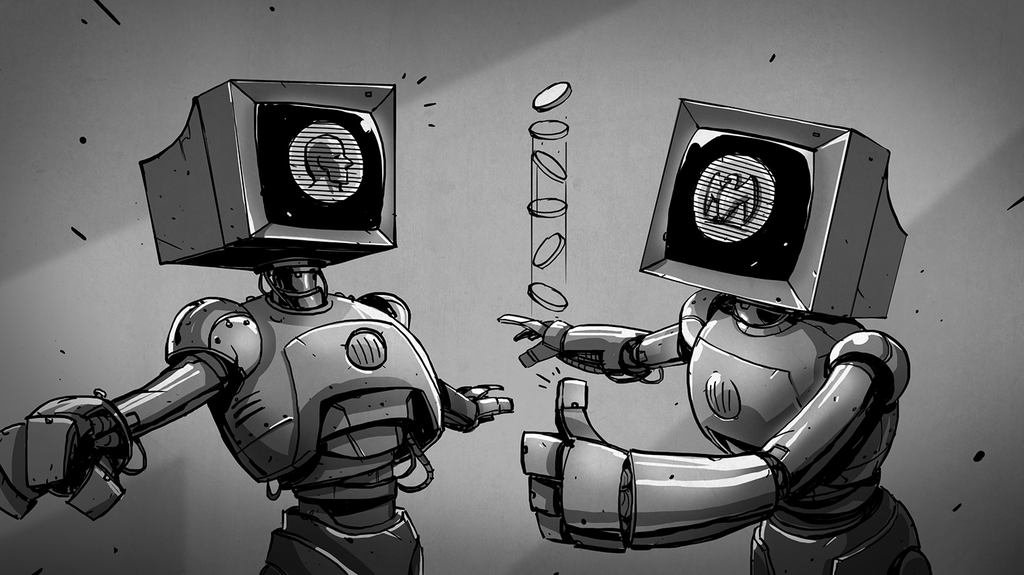

Image source: [Hackaday](https://hackaday.com/wp-content/uploads/2014/12/randomness.jpg)

Finally, let’s try to build a `CommonCoin` between two parties Alice and Bob.

If the two parties are physically next to each other, then the problem is easy to solve!

- Alice can throw the coin in the air
- Bob watches to make sure the coin toss is fair

**Question.** Can we replicate coin tossing in the digital world? If so, how?

Remember the properties of a physical coin that we want to replicate in the digital world.

- *Common view*. Once the coin is flipped, everyone can agree on the result.
- *Unpredictability*. No coalition of $f < n$ parties know what the result of the coin will be in advance.
- *Unbiasedness*. No coalition of $f < n$ parties can influence the outcome of the coin. That is, they cannot bias the result away from a 50-50 chance of heads vs tails.

**Answer.** This question is actually difficult to solve. Some initial ideas that sound promising do not work, such as saying that Alice should record a video of tossing a coin and send it to Bob. There are several ways for Alice to bias the output of the coin toss.

1. Alice can use a biased coin.
2. Alice can select the output she likes. Assume that Alice prefers an outcome of `tails`. She can create recordings of throwing the coin as many times as necessary until the outcome is `tails`. She can send only the final video to Bob.

In fact, it turns out that a perfectly fair coin toss between two parties is actually *impossible*! No matter how you design the protocol, there will always be some potential for bias by one of the two parties.

So let’s try to do the next best thing: find a way to provide a fair coin toss if the parties are honest, and to detect if they ever act maliciously.

### Commit and Reveal method

The problem with the previous approach was that the result of the coin toss depends only on Alice. As a result, Alice can flip many coins and select the output that she likes.

What if the final coin output depends on both Alice and Bob’s input equally? Can Alice still cheat?

Let’s consider the following protocol:

1. Alice picks a bit $b_1$ and a secret salt $s$ at random. Alice commits to $b_1$ by sending $h = \text{SHA-256}(b_1, s)$ to Bob.
2. Bob picks a bit $b_2$ at random.
3. Alice reveals $b_1$ and the salt $s$ to Bob. Then, Bob checks that Alice told the truth by checking that
   $$h \overset{?}{==} \text{SHA-256}(b_1, s).$$
4. If the check passes, then Bob sends his bit $b_2$ to Alice.

Both parties output $b_1$ `xor` $b_2$.

**Question**. Is this a good two-party coin tossing protocol?

Let’s try to run this protocol together right now. I will play the role of Alice, and you play the role of Bob.

For step 1 of the protocol: here is the hash of a value I personally committed to previously: `497780967d5a3d0df654d2b9099f6db3f89067008b6e1b5ec02b7e36d63b58ce`

Now, Bob needs to select a bit 0 or 1.

Finally, I as Alice need to reveal my bit and salt.

```python
import hashlib
salt = b"this is a salt"
b = b"0"

print(hashlib.sha256(b + salt).hexdigest())
```

```
497780967d5a3d0df654d2b9099f6db3f89067008b6e1b5ec02b7e36d63b58ce
```

Can Alice bias the result of the two-party coin toss?

- If she completes the protocol in a way that Bob’s verification check is successful, then no! The first step is a binding **commitment** to Alice’s bit $b_1$. Due to collision resistance, there is only one opening that Alice knows.
- Alice could refuse to complete the protocol, in which case we have no output. The only good news here is that Alice hasn’t learned anything either: she committed to her random value and cannot change it before seeing Bob’s value.

Can Bob bias the result of the two-party coin toss?

- If Bob is honest, then he chooses $b_2$ in step 2 before he sees Alice’s bit $b_1$. Bob doesn’t know what value Alice has chosen because the output of the hash function looks random.
- But if Bob is malicious, he could wait and choose the bit in step 4, and therefore entirely control the result of the coin toss!
- One way to fix this problem is to have Bob send a commitment to his bit in step 2, just like Alice did in step 1.
- However, this introduces a new problem of **selective failure**: Bob knows the result of the coin toss after step 3, whereas Alice will not learn it until step 4. If Bob realizes the result of the coin toss is bad for him, then he can refuse to complete the protocol!

In this way, a malicious Bob can bias the coin toss. As a result, Alice and Bob could use this protocol for secure coin tossing over the telephone or internet, but it is crucial for Alice not to play again if Bob refuses to reveal $b_2$. Otherwise, Bob can bias the coin by refusing to complete the protocol when the output is not in his favor.

### Generalizing CommonCoin

We can generalize the commit and reveal method we used in the two party setting to the multi-party setting with $n$ parties. The protocol would work in the following way.

1. All $n$ parties commit to their random bit and salt.
2. All $n$ parties supply their input and salt.
3. The bit of all parties are aggregated using the `xor` function.

**Question.** Can you describe an attack on this new `CommonCoin` protocol?

Here is one problem: in Round 2, an attacker Mallory would wait for everyone else to send their salt. The attacker would compute the output with and without their own input bit. Based on that result, the attacker would choose whether to reveal their bit or abandon the protocol.

We will propose two solutions to this problem.

**Economic solution.** Let everyone who wants to participate in the randomness generation send money to a smart contract. They can only get their money back if they completed Round 2.

In case the attacker doesn’t reveal their salt properly. The attacker would get slashed and lose money. This approach will work… as long as the economic benefit of biasing the coin is less than the escrowed money that they stand to lose.

**Cryptographic solution.** A better approach is not to rely on the players to reveal their own commitments. Instead, it would be nice if the group of players can reveal any commitment of any single party. That way, no single party can choose not to reveal its own value.

In Unit 4 of this course, we will discuss ways to solve precisely this problem! (Well, if there is an honest majority $t < \frac{n}{2}$.)

- Generally, we will discuss a tool called *Secure Multi-Party Computation* that allows the set of $n$ parties to work together to compute over data that they cannot see!
- In the specific case of `CommonCoin`, we will construct a way for each party to commit to its desired bit, such that any *threshold* of the group can open the commitment… even if the original party who made the commitment later refuses to participate in opening it!